# R avanzado. Sesión 5: Optimización de varias variables

Autor/a

Afiliación

Jorge de la Vega

ITAM

Fecha de publicación

30 de octubre de 2025

# Consideraciones generales

- Usualmente los problemas se plantean como problemas de minimización. Para encontrar máximos, buscamos el mínimo del negativo de una función.

Dada la dificultad de optimización en múltiples dimensiones, se han desarrollado muchos paquetes y funciones en `R`, cada uno con sus fortalezas y debilidades. Una sugerencia a aplicar (Brian Borchers, profesor de New Mexico Tech que investiga en temas de optimización):

- Si la función es suave y diferenciable, aplicar `BFGS` (Broyden-Fletcher-Goldfarb-Shanno) o `L-BFGS-B` (esta versión incluye límites inferiores y superiores)
- Si se tienen problemas de memoria en la computadora, usar también `CG` (Gradiente conjugado)
- En otros casos, usar `Nelder-Mead` (solo en tareas de baja dimensión).
- Si la función objetivo no es suficientemente suave, ninguno de estos enfoques funcionará.

Todos estos métodos están en la función `optim`. También incluye otros métodos:

- `SANN` (Simulated Annealing, que es un método de optimización estocástico)
- `Brent` (método para un sólo parámetro, usa `optimize`) Este método combina método de bisección, método de secantes y algoritmo para encontrar raíces.
- Por otro lado, si se busca por óptimos globales, primero se puede intentar un solver global (`GenSA`, `DEoptim`, `psoptim`, `CMAES`, …)
- Para problemas de mínimos cuadrados, usar solvers especializados, ya que la función es conveza y tiene un mínimo global.

La función `optim` usa por default Nelder-Mead ya que es un método robusto pero lento, que trabaja bien para funciones no diferenciables. Requiere que la función se de con input un vector, y regresa un escalar.

# Ejemplos para funciones de varias variables

## `optim` con Nelder-Mead (default)

Este método, que también se conoce con el nombre de **método simplex descendiente** no requiere que se de nada adicional a la función objetivo y un valor inicial.

### Ejemplo 1

Consideremos la siguiente función que surge en procesos químicos industriales:

$$f(x,y) = \frac{1}{x} + \frac{1}{y} + \frac{1-y}{y(1-x)} + \frac{1}{(1-x)(1-y)} \qquad x,y\in (0,1)$$

```r
f <- function(x,y){
  1/x + 1/y + (1-y)/(y*(1-x)) + 1/((1-x)*(1-y))
}
x <- y <- seq(0.1,0.9, by = 0.02)
z <- outer(x,y,f)
persp3d(x,y,z, col="red")
```

[interactive chart not shown]

Redefinir la función para `optim`, que requiere como argumento de la función un vector y no las entradas individuales.

```r
f <- function(z){
  x <- z[1]
  y <- z[2]
  1/x + 1/y + (1-y)/(y*(1-x)) + 1/((1-x)*(1-y))
}
optim(c(0.5,0.5),f)
```

```
$par
[1] 0.3636913 0.5612666

$value
[1] 9.341785

$counts
function gradient
      55       NA

$convergence
[1] 0

$message
NULL
```

La lectura de la salida es la siguiente:

- `par` da el punto donde se alcanza el mínimo
- `value` es el valor de la función en el mínimo
- `counts` cuenta el número de iteraciones que se hicieron del algoritmo. Si se provee un gradiente, dice cuántas veces se evaluó el gradiente.
- `convergence` indica si se alcanzó convergencia en el algoritmo. El código es 0 para éxito en la convergencia.

### Ejemplo 2

Otra función es la función banana, que se utiliza mucho como benchmark para comparar métodos:

```r
f <- function(x,y){
  100*(y-x^2)^2+ (1-x)^2
}
x <- y <- seq(-1.2,1, by = 0.1)
z <- outer(x,y,f)
persp3d(x,y,z, col="red")
```

[interactive chart not shown]

Redefiniendo para `optim`:

```r
f <- function(z){
  x <- z[1]
  y <- z[2]
  100*(y-x^2)^2+ (1-x)^2
}
optim(par = c(0,0),fn = f)
```

```
$par
[1] 0.9999564 0.9999085

$value
[1] 3.729052e-09

$counts
function gradient
     169       NA

$convergence
[1] 0

$message
NULL
```

## `optim` con el método BFGS

A veces se puede obtener una solución más rápida y adecuada si se cuenta con una forma analítica del gradiente de la función. Este es el enfoque de BGFS que usa una adaptación del método de Newton, aproximando $f(x)$ por una función cuadrática alrededor del valor actual del vector $x$:
$$f(x_k+h) = f(x_k) + f'(x_k)h + \frac{1}{2}f''(x_k)h^2$$

donde $f'(x)=\nabla f(x)$ es el gradiente de $f$ y $f''(x)=\nabla^2f(x)=H_f(x)$ es la matriz hessiana de $f$, y tomando luego un paso hacia el mínimo (o máximo) de la función cuadrática. En el óptimo, el gradiente es 0.

El método de Newton es un método iterativo para encontrar las raíces de una función doblemente diferenciable y se buscan los valores críticos $x$ tal que $f'(x)=0$

La siguiente función calcula el gradiente de la función y lo evalúa en un punto:

```r
grad <- function(z){
  x <- z[1]
  y <- z[2]
  c(-400*x*(y-x^2)-2*(1-x), 200*(y-x^2))
}

optim(par = c(-1.2,1),
      fn = f,
      gr = grad,
      method = "BFGS",
      hessian = F) # si se quiere el hessiano evaluado en el punto, se pone T
```

```
$par
[1] 1 1

$value
[1] 9.594956e-18

$counts
function gradient
     110       43

$convergence
[1] 0

$message
NULL
```

Aquí la función se evalúo 110 veces, y 43 veces el gradiente, mientras que con el método de Nelder-Mead se hicieron 169 evaluaciones.

## Paquete optimx

Este paquete es un envoltorio (*wrapper*) para varias rutinas de optimización. Uno de los propósitos del paquete es unificar las llamadas a varios optimizadores útiles en una sintaxis común y permitir comparar su desempeño.

Alguno de los optimizadores que incluye son los siguientes: `Nelder-Mead`, `BFGS`, `CG`, `L-BFGS-B`, `nlm`, `nlminb`, `spg`, `ucminf`, `newuoa`, `bobyqa`, `nmkb`, `hjkb`, `Rcgmin`, `Rvmmin`.

Consideremos un ejemplo usando de nuevo la función banana:

```r
require(optimx)

f <- function(x){
  # banana de Rosenbrock
  u <- x[1]
  v <- x[2]
  100*(v-u^2)^2 + (1-u)^2
}


grad <- function(z){
  # gradiente de la función banana
  x <- z[1]
  y <- z[2]
  c(-400*x*(y-x^2)-2*(1-x), 200*(y-x^2))
}


x0 <- c(-1.2,1)

ajuste <- optimx(par=x0, fn = f, gr = grad, control=list(all.methods = T))
summary(ajuste, order = value)
```

```
                    p1        p2        value fevals gevals niter convcode  kkt1  kkt2 xtime
Rvmmin       1.0000000 1.0000000 1.232595e-32     59     39    NA        2  TRUE  TRUE 0.001
nlminb       1.0000000 1.0000000 4.291936e-22     43     36    35        0  TRUE  TRUE 0.001
nlm          1.0000000 1.0000000 1.182096e-20     NA     NA    24        0  TRUE  TRUE 0.000
BFGS         1.0000000 1.0000000 9.594956e-18    110     43    NA        0  TRUE  TRUE 0.000
ucminf       1.0000000 1.0000000 2.725670e-17     38     38    NA        0  TRUE  TRUE 0.002
newuoa       1.0000000 0.9999999 2.177737e-15    257     NA    NA        0  TRUE  TRUE 0.038
Rcgmin       0.9999998 0.9999997 2.679582e-14    111     54    NA        0  TRUE  TRUE 0.001
L-BFGS-B     0.9999997 0.9999995 2.267788e-13     47     47    NA        0  TRUE  TRUE 0.001
bobyqa       1.0000005 1.0000009 2.844885e-13    290     NA    NA        0  TRUE  TRUE 0.001
spg          0.9998027 0.9996047 3.898009e-08    141     NA   112        0  TRUE  TRUE 0.005
hjkb         0.9997070 0.9994125 8.609045e-08    476     NA    19        0  TRUE  TRUE 0.001
Nelder-Mead  1.0002601 1.0005060 8.825241e-08    195     NA    NA        0 FALSE  TRUE 0.000
nmkb         1.0002749 1.0006092 4.268664e-07    120     NA    NA        0 FALSE  TRUE 0.003
CG          -0.7648373 0.5927588 3.106579e+00    402    101    NA        1 FALSE FALSE 0.000
```

# Ejemplos de problemas de estimación vía máxima verosimilitud

La verosimilitud trata de maximizar la probabilidad de que una distribución conjunta con ciertos parámetros, resulte en la muestra obtenida. Para esto se define la *función de verosimilitud*

**Definición 1 (Función de verosimilitud)** Sea $X_1,\ldots, X_n$ una muestra aleatoria (independiente e idénticamente distribuída, o iid). de una población con función de densidad $f(x|\theta)$. Se define la función de verosimilitud como la función de densidad conjunta de la muestra, vista como función del parámetro $\theta$:

$$L(\theta) = f_{X_1,\ldots,X_n}(x_1,\ldots,x_n|\theta) = \prod_{i=1}^nf_{X_i}(x_i|\theta)$$

El estimador máximo-verosímil es un estimador $\hat{\theta}=T(X_1,\ldots.X_n)$ tal que para cualquier $\theta\in \Theta$, se tiene que $L(\hat{\theta})\geq L(\theta)$

Entonces para encontrar el estimador máximo-verosímil, se tiene que maximizar la función de verosimilitud $L(\theta)$. Esto se puede hacer tomando las derivadas de los parámetros y formando un sistema de ecuaciones para encontrar los valores óptimos.

En muchas ocasiones, es mejor tomar la log-verosimilitud $l(\theta) = \log(L(\theta))$, ya que tienen el mismo máximo.

### E1: Estimadores de verosimilitud para una distribución Gamma.

En muchos problemas reales, no podemos encontrar los estimadores máximo-verosímiles de manera analítica, por lo que se requiere resolver por métodos numéricos. En `R` hay diferentes funciones que sirven para resolver los problemas de optimización.

Sea $X_1,\ldots,X_n \sim Gamma(\alpha,\beta)$ donde
$$f(x|\alpha,\beta) = \frac{1}{\Gamma(\alpha)\beta^{\alpha}}x^{\alpha-1}e^{-x/\beta}I(x>0).$$

La función de verosimilitud es:

$$L(\alpha,\beta) = \prod_{i=1}^n \frac{1}{\Gamma(\alpha)\beta^{\alpha}}x^{\alpha-1}e^{-x/\beta}$$

Obteniendo la log-verosimilitud:

$$\begin{eqnarray*}
l(\alpha,\beta) &=& \sum_{i=1}^n\left( -\log(\Gamma(\alpha)) -\alpha\log(\beta) + (\alpha-1)\log(x_i)-x_i/\beta \right) \\
&=& -n\log(\Gamma(\alpha)) - n\alpha\log(\beta) + (\alpha-1)\sum_{i=1}^n\log(x_i) - \sum_{i=1}^nx_i/\beta
\end{eqnarray*}$$

Obviamente necesitamos contar con una muestra aleatoria de la cual vamos a estimar los parámetros. Aquí generamos por simulación una muestra de gammas y tratamos de reproducir los parámetros estimados. La semilla aleatoria se fija para reproducibilidad

```r
set.seed(19681206) # Fijamos semilla aleatoria para reproducibilidad
x <- rgamma(100,shape = 2, scale = 5)  # Se genera una muestra aleatoria gamma(2,5)
head(x)
```

```
[1]  3.273146  5.109838 12.858649  3.695356  8.573222 11.683674
```

Definimos la función de log-verosimilitud

```r
# Función de log-verosimilitud
lgamma <- function(th,x){
            a <- th[1]
            b <- th[2]
            n <- length(x)
            -(-n*log(gamma(a)) - n*a*log(b) + (a-1)*sum(log(x)) - (1/b)*sum(x))
        }

(thoptim <- optim(c(1,3), lgamma, x = x)$par)  # valores óptimos.
```

```
[1] 2.022161 5.019097
```

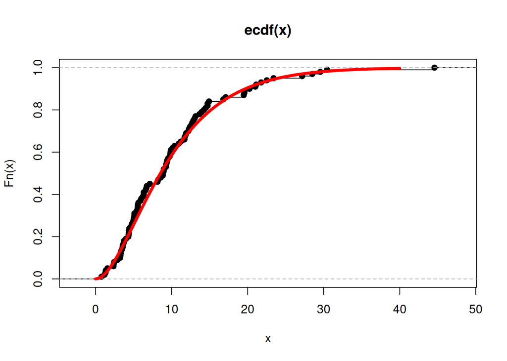

```r
# Distribución empirica
plot(ecdf(x))
curve(pgamma(x, shape = thoptim[1], scale = thoptim[2]),
             from = 0, to = 40, add=T, col = "red", lwd = 4)
```

### E2: Ajuste de un modelo de mezclas

Los tiempos de espera entre erupciones del geiser ‘Old Faithful’ en el Parque Nacional Yosemith son fuertemente bimodales.

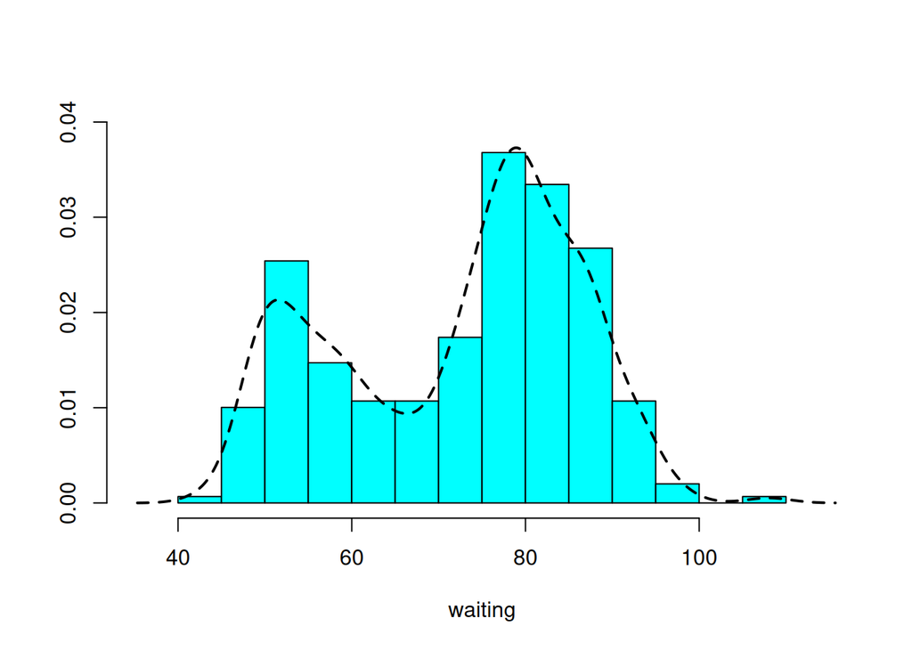

```r
library(MASS)
with(geyser,
     truehist(waiting, xlim = c(35,115), ymax = 0.04, h=5))
espera.dens <- density(geyser$waiting, n = 512, width = "SJ")
lines(espera.dens, lty = 2, lwd=2)
```

En estos datos, parece razonable ajustar una mezcla de normales para la distribución marginal de los tiempos de espera entre erupciones.

En este ejemplo, como las observaciones forman una serie de tiempo, no son independientes; de hecho tienen autocorrelación negativa con la observación previa:

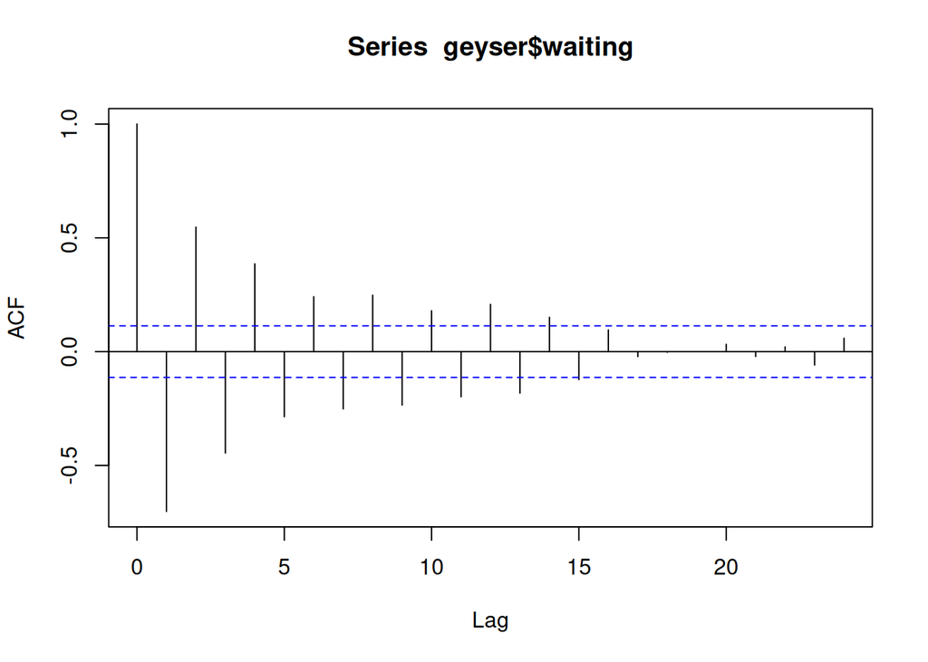

```r
acf(geyser$waiting)
```

Pero para efectos de la estimación, ignoraremos este hecho por simplicidad y ajustaremos la función vía máxima verosimilitud. El vector $\theta$ tiene 5 componentes: el coeficiente de la mezcla $p$, y los parámetros de dos normales:

$$l(p,\mu_1,\sigma_1,\mu_2,\sigma_2) = \sum_{i=1}^n\log\left[ \frac{p}{\sigma_1}\phi\left(\frac{x_i-\mu_1}{\sigma_1}\right) + \frac{1-p}{\sigma_2}\phi\left(\frac{x_i-\mu_2}{\sigma_2}\right)\right]$$

Aquí estimamos los parámetros minimizando $-l$.

En este ejemplo podemos usar información de la primera y segunda derivada y usar la función `deriv` que calcula la derivada simbólica de expresiones simples para definir la función objetivo. Esta función puede usar las funciones de normales `pnorm` y `dnorm` con un solo argumento, por lo que debemos pasarlo en el formato `pnorm((x-u/s))` en lugar de `pnorm(x,u,s)`. Podemos generar una función que calcula los sumandos de $-l$ y regresa la primera y segunda derivada de cada sumando:

```r
lmix2 <- deriv(
              ~ -log((p/s1)*dnorm((x-u1)/s1) + ((1-p)/s2)*dnorm((x-u2)/s2)),
              c("p","u1","s1","u2","s2"),
              function(x,p,u1,s1,u2,s2) NULL)
```

A partir de la gráfica, podemos dar valores algunos valores iniciales, por ejemplo:

```r
(p0 <- c(p = mean(geyser$waiting < 70), u1 = 50, s1 = 5, u2 = 80, s2 = 5))
```

```
        p        u1        s1        u2        s2
 0.361204 50.000000  5.000000 80.000000  5.000000
```

#### Usando la función `nlminb`

La rutina de minimización más general de `R` es `nlminb` que puede encontrar un mínimo local de una función que es doblemente diferenciable en un hipercubo del espacio parametral. Se pueden dar ya sea el gradiente o el gradiente más el hessiano. Si no se da, se aproxima por diferencias finitas.

El algoritmo subyacente es un optimizador quasi-Newton o Newton si se da el hessiano. Entonces con este algoritmo podemos ajustar la densidad mezcla y forzar las restricciones.

Por ejemplo, sin derivadas:

```r
mix.obj <- function(p,x){
  e <- (p[1]/p[3]) * dnorm((x-p[2])/p[3]) + ((1-p[1])/p[5])*dnorm((x-p[4])/p[5])
  return(-sum(log(e)))
}

(mix.n10 <- nlminb(start = p0,
                  objective = mix.obj,
                  scale = c(10,rep(1,4)),
                  lower = c(0,-Inf,0,-Inf,0),  # valores mínimos de los parámetros
                  upper = c(1,rep(Inf,4)),     # valores máximos de los parámetros
                  x = geyser$waiting))
```

```
$par
         p         u1         s1         u2         s2
 0.3075948 54.2026466  4.9520202 80.3603113  7.5076130

$objective
[1] 1157.542

$convergence
[1] 0

$iterations
[1] 14

$evaluations
function gradient
      20       97

$message
[1] "relative convergence (4)"
```

Aquí se usó el argumento `scale` para establecer la longitud de los pasos en el primer parámetro para que sean más chicos que los de los otros parámetros ($p\in (0,1)$) para que se acelere la convergencia

**NotaRecomendación:**

Es útil establecer la escala de tal manera que el rango de incertidumbre en (escala $\times$ parámetro) esté cerca de 1.

Usando una derivada (gradiente):

```r
# la diferencia con la previa lmix2 es que ésta calcula el hessiano
lmix2a <- deriv(
            ~ -log((p/s1)*dnorm((x-u1)/s1) + ((1-p)/s2)*dnorm((x-u2)/s2)),
            c("p","u1","s1","u2","s2"), hessian = T,
            function(x,p,u1,s1,u2,s2) NULL)

mix.gr <- function(p,x){
  u1 <- p[2]
  s1 <- p[3]
  u2 <- p[4]
  s2 <- p[5]
  p <-  p[1]
  colSums(attr(lmix2a(x,p,u1,s1,u2,s2), "gradient"))
}

(mix.nl1 <- nlminb(start = p0,
                  objective = mix.obj,
                  gradient = mix.gr,
                  scale = c(10, rep(1,4)),
                  lower = c(0,-Inf, 0, -Inf, 0),
                  upper = c(1, rep(Inf,4)),
                  x = geyser$waiting))
```

```
$par
         p         u1         s1         u2         s2
 0.3075938 54.2026561  4.9519971 80.3603062  7.5076451

$objective
[1] 1157.542

$convergence
[1] 0

$iterations
[1] 15

$evaluations
function gradient
      21       16

$message
[1] "relative convergence (4)"
```

Usando dos derivadas (gradiente y hessiano)

```r
mix.gr <- function(p,x){
  e <- lmix2a(x, p[1], p[2], p[3], p[4], p[5])
  g <- colSums(attr(e, "gradient"))
  return(g)
}

mix.hess <- function(p,x){
  e <- lmix2a(x, p[1], p[2], p[3], p[4], p[5])
  H <- colSums(attr(e, "hessian"), 2)
  return(H)
}

(mix.nl2 <- nlminb(start = p0,
                  objective = mix.obj,
                  gradient = mix.gr,
                  hessian = mix.hess,
                  scale = c(10, rep(1,4)),
                  lower = c(0,-Inf, 0, -Inf, 0),
                  upper = c(1, rep(Inf,4)),
                  x = geyser$waiting))
```

```
$par
         p         u1         s1         u2         s2
 0.3075936 54.2026490  4.9520013 80.3603091  7.5076364

$objective
[1] 1157.542

$convergence
[1] 0

$iterations
[1] 6

$evaluations
function gradient
       8        7

$message
[1] "relative convergence (4)"
```

Agregamos la solución encontrada al histograma para comparar:

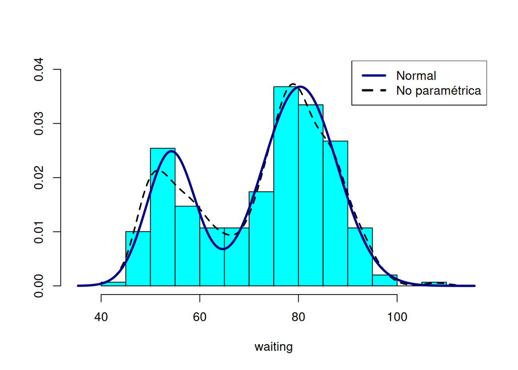

```r
with(geyser,
     truehist(waiting, xlim = c(35,115), ymax = 0.04, h=5))
wait.dens <- density(geyser$waiting, n = 512, width = "SJ")
lines(wait.dens, lty = 2, lwd=2)

dmix2 <- function(x, p, u1, s1, u2, s2) p*dnorm(x,u1,s1) + (1-p)*dnorm(x, u2, s2)
parametros <- mix.nl2$par
tiempos <- list(x = wait.dens$x,
                y = dmix2(wait.dens$x,
                          parametros[1],
                          parametros[2],
                          parametros[3],
                          parametros[4],
                          parametros[5]))
lines(tiempos, col = "navy", lwd = 3)
legend("topright", c("Normal","No paramétrica"),
       lty=c(1,2), col = c("navy","black"), lwd = 3)
```

### Algoritmo EM

El algoritmo de *Expectation-Maximization* (Dempster, Laird & Rubin, 1977) es un método general de optimización que se aplica usualmente cuando hay datos incompletos.

- Usualmente es lento, pero muy confiable para encontrar máximos globales.
- Se inicia con un estimado del parámetro objetivo y luego se alterna entre dos pasos: el paso E y el paso M:
  - **paso E**: se calcula la esperanza condicional de la función objetivo, que usualmente es una log-verosimilitud dados los datos observados y los parámetros estimados actualmente: $Q(\theta; \theta_{t-1}) = E(l(\theta)| X,\theta_{t-1})$.
  - **Paso M**: se maximiza la esperanza condicional con respecto al parámetro objetivo y se actualizan los parámetros: $\theta_{t+1} = \max_{\theta} Q(\theta,\theta_{t})$, y se hace $\theta_{t}=\theta_{t+1}$
- El algoritmo sigue hasta que se alcanza convergencia.

Por ejemplo, consideremos lel problema de estimar los parámetros de una forma cuadrática de variables normales centradas:
$$Y = \sum_{i=1}^k \lambda_iZ_i^2$$
donde $Z_i\sim N(0,1)$ independientes, y $\lambda_1>\lambda_2>\cdots > \lambda_k>0$. El problema es equivalente a un problema de mezcla de gammas, ya que $\lambda Z^2 \equiv \lambda \chi^2_{1}$ que a su vez es equivalente a una $\Gamma(1/2,1/(2\lambda))$. Entonces $Y$ es una mezcla de k gammas independientes:
$$Y \stackrel{d}{=} \sum_{i=1}^k\frac{1}{k}Gamma\left(\frac{1}{2},\frac{1}{2\lambda_i}\right)$$

En este caso la log-verosimilitud es $l(\lambda)=\sum_{i=1}^kf_i(x|\lambda)$.

Supongamos que $k=3$ y que se tiene una muestra observada de $m$ observaciones.

El algoritmo EM primero actualiza la probabilidad posterior $p_{ij}$ de que la observación $y_i$ viene de la población $j$. En el paso $r$:
$$p_{ij}^{(r)} = \frac{\frac{1}{k}f_j(y_i|y,\lambda^{(r)})}{\sum_{m=1}^k\frac{1}{k}f_m(y_m|y,\lambda^{(r)})}$$
donde $\lambda^{(r)}$ es el estimador del paso $r$ de los parámetros $\{\lambda_j\}$ y $f_j(y_i|y,\lambda^{(r)})$ es la densidad Gamma con parámetros $1/2$ y $1/(2\lambda^{(r)})$ evaluada en $y_i$. Como la media de la $j-$ésima componente es $\lambda_j$, así que la ecuación a actualizar es
$$\mu_j^{(r+1)} = \frac{\sum_{l=1}^mp_{ij}^{(r)}y_i}{\sum p_{ij}^{(r)}}$$

A continuación generamos una muestra de $m=2000$ observaciones de la mezcla con parámetros $\lambda_1=0.6$, $\lambda_2=0.25$ y $\lambda_3=0.15$.

```r
m <- 2000
set.seed(1968)
lambda <- c(0.6, 0.25, 0.15) # la tasa es 1/(2lambda)
lam <- sample(lambda, size = m, replace=T)
y <- rgamma(m, shape = 0.5, rate = 1/(2*lam))
```

Este código construye el algoritmo EM

```r
N <- 10000  # max número de iteraciones del algoritmo
L <- c(0.5,0.4,0.1)  # valor inicial de lambda
tol <- sqrt(.Machine$double.eps) # tolerancia
L.old <- L + 1  # valor de comparación inicial.
g <- function(y,l)dgamma(y,shape = 1/2, rate=1/(2*l))

for(j in 1:N){

  f1 <- g(y,L[1])
  f2 <- g(y,L[2])
  f3 <- g(y,L[3])
  py <- f1/(f1+f2+f3)  # posterior de 1
  qy <- f2/(f1+f2+f3)  # posterior de 2
  ry <- f3/(f1+f2+f3)  # posterior de 3


  mu1 <- sum(y*py)/sum(py)
  mu2 <- sum(y*qy)/sum(qy)
  mu3 <- sum(y*ry)/sum(ry)
  L <- c(mu1, mu2, mu3) # actualiza lambdas
  L <- L/sum(L)

  if (sum(abs(L-L.old)/L.old) < tol ) break
  L.old <- L
}

print(list(lambda = L/sum(L), iter = j, tol = tol))
```

```
$lambda
[1] 0.6051422 0.2462299 0.1486280

$iter
[1] 459

$tol
[1] 1.490116e-08
```

El algoritmo convirgió en 459 pasos.